# Optimal Treatment Analysis

## Outcome Variable

**Outcome Variable:** ever_stunted

## Predictor Variables

**Intervention Variable:** lag_WHZ_quart

**Adjustment Set:**

- arm
- sex
- W_mage
- meducyrs
- feducyrs
- single
- month
- brthmon
- delta_W_mage
- delta_meducyrs
- delta_feducyrs
- delta_single
- delta_month
- delta_brthmon

## Stratifying Variables

The analysis was stratified on these variable(s):

- agecat
- studyid
- country

## Data Summary

| agecat | studyid | country | lag_WHZ_quart | ever_stunted | n_cell | n |
| --- | --- | --- | --- | --- | --- | --- |
| 3-6 months | ki0047075b-MAL-ED | BANGLADESH | 1 | 0 | 43 | 207 |
| 3-6 months | ki0047075b-MAL-ED | BANGLADESH | 1 | 1 | 5 | 207 |
| 3-6 months | ki0047075b-MAL-ED | BANGLADESH | 2 | 0 | 78 | 207 |
| 3-6 months | ki0047075b-MAL-ED | BANGLADESH | 2 | 1 | 14 | 207 |
| 3-6 months | ki0047075b-MAL-ED | BANGLADESH | 3 | 0 | 51 | 207 |
| 3-6 months | ki0047075b-MAL-ED | BANGLADESH | 3 | 1 | 8 | 207 |
| 3-6 months | ki0047075b-MAL-ED | BANGLADESH | 4 | 0 | 7 | 207 |
| 3-6 months | ki0047075b-MAL-ED | BANGLADESH | 4 | 1 | 1 | 207 |
| 3-6 months | ki0047075b-MAL-ED | BRAZIL | 1 | 0 | 32 | 201 |
| 3-6 months | ki0047075b-MAL-ED | BRAZIL | 1 | 1 | 1 | 201 |
| 3-6 months | ki0047075b-MAL-ED | BRAZIL | 2 | 0 | 90 | 201 |
| 3-6 months | ki0047075b-MAL-ED | BRAZIL | 2 | 1 | 5 | 201 |
| 3-6 months | ki0047075b-MAL-ED | BRAZIL | 3 | 0 | 50 | 201 |
| 3-6 months | ki0047075b-MAL-ED | BRAZIL | 3 | 1 | 3 | 201 |
| 3-6 months | ki0047075b-MAL-ED | BRAZIL | 4 | 0 | 16 | 201 |
| 3-6 months | ki0047075b-MAL-ED | BRAZIL | 4 | 1 | 4 | 201 |
| 3-6 months | ki0047075b-MAL-ED | INDIA | 1 | 0 | 65 | 199 |
| 3-6 months | ki0047075b-MAL-ED | INDIA | 1 | 1 | 13 | 199 |
| 3-6 months | ki0047075b-MAL-ED | INDIA | 2 | 0 | 65 | 199 |
| 3-6 months | ki0047075b-MAL-ED | INDIA | 2 | 1 | 9 | 199 |
| 3-6 months | ki0047075b-MAL-ED | INDIA | 3 | 0 | 30 | 199 |
| 3-6 months | ki0047075b-MAL-ED | INDIA | 3 | 1 | 8 | 199 |
| 3-6 months | ki0047075b-MAL-ED | INDIA | 4 | 0 | 4 | 199 |
| 3-6 months | ki0047075b-MAL-ED | INDIA | 4 | 1 | 5 | 199 |
| 3-6 months | ki0047075b-MAL-ED | NEPAL | 1 | 0 | 43 | 210 |
| 3-6 months | ki0047075b-MAL-ED | NEPAL | 1 | 1 | 0 | 210 |
| 3-6 months | ki0047075b-MAL-ED | NEPAL | 2 | 0 | 80 | 210 |
| 3-6 months | ki0047075b-MAL-ED | NEPAL | 2 | 1 | 2 | 210 |
| 3-6 months | ki0047075b-MAL-ED | NEPAL | 3 | 0 | 68 | 210 |
| 3-6 months | ki0047075b-MAL-ED | NEPAL | 3 | 1 | 3 | 210 |

[output cut: 882 more lines]

The following strata were considered:

- agecat: 12-15 months, studyid: ki0047075b-MAL-ED, country: BANGLADESH
- agecat: 12-15 months, studyid: ki0047075b-MAL-ED, country: BRAZIL
- agecat: 12-15 months, studyid: ki0047075b-MAL-ED, country: INDIA
- agecat: 12-15 months, studyid: ki0047075b-MAL-ED, country: NEPAL
- agecat: 12-15 months, studyid: ki0047075b-MAL-ED, country: PERU
- agecat: 12-15 months, studyid: ki0047075b-MAL-ED, country: SOUTH AFRICA
- agecat: 12-15 months, studyid: ki0047075b-MAL-ED, country: TANZANIA, UNITED REPUBLIC OF
- agecat: 12-15 months, studyid: ki1000108-CMC-V-BCS-2002, country: INDIA
- agecat: 12-15 months, studyid: ki1000108-IRC, country: INDIA
- agecat: 12-15 months, studyid: ki1000109-EE, country: PAKISTAN
- agecat: 12-15 months, studyid: ki1017093b-PROVIDE, country: BANGLADESH
- agecat: 12-15 months, studyid: ki1066203-TanzaniaChild2, country: TANZANIA, UNITED REPUBLIC OF
- agecat: 12-15 months, studyid: ki1101329-Keneba, country: GAMBIA
- agecat: 12-15 months, studyid: ki1112895-Guatemala BSC, country: GUATEMALA
- agecat: 12-15 months, studyid: ki1113344-GMS-Nepal, country: NEPAL
- agecat: 12-15 months, studyid: ki1114097-CMIN, country: BANGLADESH
- agecat: 12-15 months, studyid: ki1114097-CMIN, country: PERU
- agecat: 15-18 months, studyid: ki0047075b-MAL-ED, country: BANGLADESH
- agecat: 15-18 months, studyid: ki0047075b-MAL-ED, country: BRAZIL
- agecat: 15-18 months, studyid: ki0047075b-MAL-ED, country: INDIA
- agecat: 15-18 months, studyid: ki0047075b-MAL-ED, country: NEPAL
- agecat: 15-18 months, studyid: ki0047075b-MAL-ED, country: PERU
- agecat: 15-18 months, studyid: ki0047075b-MAL-ED, country: SOUTH AFRICA
- agecat: 15-18 months, studyid: ki0047075b-MAL-ED, country: TANZANIA, UNITED REPUBLIC OF
- agecat: 15-18 months, studyid: ki1000108-CMC-V-BCS-2002, country: INDIA
- agecat: 15-18 months, studyid: ki1000108-IRC, country: INDIA
- agecat: 15-18 months, studyid: ki1000109-EE, country: PAKISTAN
- agecat: 15-18 months, studyid: ki1017093b-PROVIDE, country: BANGLADESH
- agecat: 15-18 months, studyid: ki1066203-TanzaniaChild2, country: TANZANIA, UNITED REPUBLIC OF
- agecat: 15-18 months, studyid: ki1101329-Keneba, country: GAMBIA
- agecat: 15-18 months, studyid: ki1112895-Guatemala BSC, country: GUATEMALA
- agecat: 15-18 months, studyid: ki1113344-GMS-Nepal, country: NEPAL
- agecat: 15-18 months, studyid: ki1114097-CMIN, country: BANGLADESH
- agecat: 15-18 months, studyid: ki1114097-CMIN, country: PERU
- agecat: 18-21 months, studyid: ki0047075b-MAL-ED, country: BANGLADESH
- agecat: 18-21 months, studyid: ki0047075b-MAL-ED, country: BRAZIL
- agecat: 18-21 months, studyid: ki0047075b-MAL-ED, country: INDIA
- agecat: 18-21 months, studyid: ki0047075b-MAL-ED, country: NEPAL
- agecat: 18-21 months, studyid: ki0047075b-MAL-ED, country: PERU
- agecat: 18-21 months, studyid: ki0047075b-MAL-ED, country: SOUTH AFRICA
- agecat: 18-21 months, studyid: ki0047075b-MAL-ED, country: TANZANIA, UNITED REPUBLIC OF
- agecat: 18-21 months, studyid: ki1000108-CMC-V-BCS-2002, country: INDIA
- agecat: 18-21 months, studyid: ki1000108-IRC, country: INDIA
- agecat: 18-21 months, studyid: ki1000109-EE, country: PAKISTAN
- agecat: 18-21 months, studyid: ki1017093b-PROVIDE, country: BANGLADESH
- agecat: 18-21 months, studyid: ki1066203-TanzaniaChild2, country: TANZANIA, UNITED REPUBLIC OF
- agecat: 18-21 months, studyid: ki1101329-Keneba, country: GAMBIA
- agecat: 18-21 months, studyid: ki1113344-GMS-Nepal, country: NEPAL
- agecat: 18-21 months, studyid: ki1114097-CMIN, country: BANGLADESH
- agecat: 18-21 months, studyid: ki1114097-CMIN, country: PERU
- agecat: 21-24 months, studyid: ki0047075b-MAL-ED, country: BANGLADESH
- agecat: 21-24 months, studyid: ki0047075b-MAL-ED, country: BRAZIL
- agecat: 21-24 months, studyid: ki0047075b-MAL-ED, country: INDIA
- agecat: 21-24 months, studyid: ki0047075b-MAL-ED, country: NEPAL
- agecat: 21-24 months, studyid: ki0047075b-MAL-ED, country: PERU
- agecat: 21-24 months, studyid: ki0047075b-MAL-ED, country: SOUTH AFRICA
- agecat: 21-24 months, studyid: ki0047075b-MAL-ED, country: TANZANIA, UNITED REPUBLIC OF
- agecat: 21-24 months, studyid: ki1000108-CMC-V-BCS-2002, country: INDIA
- agecat: 21-24 months, studyid: ki1000108-IRC, country: INDIA
- agecat: 21-24 months, studyid: ki1017093b-PROVIDE, country: BANGLADESH
- agecat: 21-24 months, studyid: ki1066203-TanzaniaChild2, country: TANZANIA, UNITED REPUBLIC OF
- agecat: 21-24 months, studyid: ki1101329-Keneba, country: GAMBIA
- agecat: 21-24 months, studyid: ki1113344-GMS-Nepal, country: NEPAL
- agecat: 21-24 months, studyid: ki1114097-CMIN, country: BANGLADESH
- agecat: 21-24 months, studyid: ki1114097-CMIN, country: PERU
- agecat: 3-6 months, studyid: ki0047075b-MAL-ED, country: BANGLADESH
- agecat: 3-6 months, studyid: ki0047075b-MAL-ED, country: BRAZIL
- agecat: 3-6 months, studyid: ki0047075b-MAL-ED, country: INDIA
- agecat: 3-6 months, studyid: ki0047075b-MAL-ED, country: NEPAL
- agecat: 3-6 months, studyid: ki0047075b-MAL-ED, country: PERU
- agecat: 3-6 months, studyid: ki0047075b-MAL-ED, country: SOUTH AFRICA
- agecat: 3-6 months, studyid: ki0047075b-MAL-ED, country: TANZANIA, UNITED REPUBLIC OF
- agecat: 3-6 months, studyid: ki1000108-CMC-V-BCS-2002, country: INDIA
- agecat: 3-6 months, studyid: ki1000108-IRC, country: INDIA
- agecat: 3-6 months, studyid: ki1000109-EE, country: PAKISTAN
- agecat: 3-6 months, studyid: ki1017093b-PROVIDE, country: BANGLADESH
- agecat: 3-6 months, studyid: ki1066203-TanzaniaChild2, country: TANZANIA, UNITED REPUBLIC OF
- agecat: 3-6 months, studyid: ki1101329-Keneba, country: GAMBIA
- agecat: 3-6 months, studyid: ki1112895-Guatemala BSC, country: GUATEMALA
- agecat: 3-6 months, studyid: ki1114097-CMIN, country: BANGLADESH
- agecat: 3-6 months, studyid: ki1114097-CMIN, country: PERU
- agecat: 6-9 months, studyid: ki0047075b-MAL-ED, country: BANGLADESH
- agecat: 6-9 months, studyid: ki0047075b-MAL-ED, country: BRAZIL
- agecat: 6-9 months, studyid: ki0047075b-MAL-ED, country: INDIA
- agecat: 6-9 months, studyid: ki0047075b-MAL-ED, country: NEPAL
- agecat: 6-9 months, studyid: ki0047075b-MAL-ED, country: PERU
- agecat: 6-9 months, studyid: ki0047075b-MAL-ED, country: SOUTH AFRICA
- agecat: 6-9 months, studyid: ki0047075b-MAL-ED, country: TANZANIA, UNITED REPUBLIC OF
- agecat: 6-9 months, studyid: ki1000108-CMC-V-BCS-2002, country: INDIA
- agecat: 6-9 months, studyid: ki1000108-IRC, country: INDIA
- agecat: 6-9 months, studyid: ki1000109-EE, country: PAKISTAN
- agecat: 6-9 months, studyid: ki1017093b-PROVIDE, country: BANGLADESH
- agecat: 6-9 months, studyid: ki1066203-TanzaniaChild2, country: TANZANIA, UNITED REPUBLIC OF
- agecat: 6-9 months, studyid: ki1101329-Keneba, country: GAMBIA
- agecat: 6-9 months, studyid: ki1112895-Guatemala BSC, country: GUATEMALA
- agecat: 6-9 months, studyid: ki1114097-CMIN, country: BANGLADESH
- agecat: 6-9 months, studyid: ki1114097-CMIN, country: PERU
- agecat: 9-12 months, studyid: ki0047075b-MAL-ED, country: BANGLADESH
- agecat: 9-12 months, studyid: ki0047075b-MAL-ED, country: BRAZIL
- agecat: 9-12 months, studyid: ki0047075b-MAL-ED, country: INDIA
- agecat: 9-12 months, studyid: ki0047075b-MAL-ED, country: NEPAL
- agecat: 9-12 months, studyid: ki0047075b-MAL-ED, country: PERU
- agecat: 9-12 months, studyid: ki0047075b-MAL-ED, country: SOUTH AFRICA
- agecat: 9-12 months, studyid: ki0047075b-MAL-ED, country: TANZANIA, UNITED REPUBLIC OF
- agecat: 9-12 months, studyid: ki1000108-CMC-V-BCS-2002, country: INDIA
- agecat: 9-12 months, studyid: ki1000108-IRC, country: INDIA
- agecat: 9-12 months, studyid: ki1000109-EE, country: PAKISTAN
- agecat: 9-12 months, studyid: ki1017093b-PROVIDE, country: BANGLADESH
- agecat: 9-12 months, studyid: ki1066203-TanzaniaChild2, country: TANZANIA, UNITED REPUBLIC OF
- agecat: 9-12 months, studyid: ki1101329-Keneba, country: GAMBIA
- agecat: 9-12 months, studyid: ki1112895-Guatemala BSC, country: GUATEMALA
- agecat: 9-12 months, studyid: ki1113344-GMS-Nepal, country: NEPAL
- agecat: 9-12 months, studyid: ki1114097-CMIN, country: BANGLADESH
- agecat: 9-12 months, studyid: ki1114097-CMIN, country: PERU

### Dropped Strata

Some strata were dropped due to rare outcomes:

- agecat: 3-6 months, studyid: ki0047075b-MAL-ED, country: BANGLADESH
- agecat: 3-6 months, studyid: ki0047075b-MAL-ED, country: BRAZIL
- agecat: 3-6 months, studyid: ki0047075b-MAL-ED, country: INDIA
- agecat: 3-6 months, studyid: ki0047075b-MAL-ED, country: NEPAL
- agecat: 3-6 months, studyid: ki0047075b-MAL-ED, country: PERU
- agecat: 3-6 months, studyid: ki0047075b-MAL-ED, country: SOUTH AFRICA
- agecat: 3-6 months, studyid: ki0047075b-MAL-ED, country: TANZANIA, UNITED REPUBLIC OF
- agecat: 3-6 months, studyid: ki1000108-CMC-V-BCS-2002, country: INDIA
- agecat: 3-6 months, studyid: ki1000108-IRC, country: INDIA
- agecat: 3-6 months, studyid: ki1000109-EE, country: PAKISTAN
- agecat: 3-6 months, studyid: ki1112895-Guatemala BSC, country: GUATEMALA
- agecat: 3-6 months, studyid: ki1114097-CMIN, country: BANGLADESH
- agecat: 6-9 months, studyid: ki0047075b-MAL-ED, country: BANGLADESH
- agecat: 6-9 months, studyid: ki0047075b-MAL-ED, country: BRAZIL
- agecat: 6-9 months, studyid: ki0047075b-MAL-ED, country: INDIA
- agecat: 6-9 months, studyid: ki0047075b-MAL-ED, country: NEPAL
- agecat: 6-9 months, studyid: ki1000108-CMC-V-BCS-2002, country: INDIA
- agecat: 6-9 months, studyid: ki1000108-IRC, country: INDIA
- agecat: 6-9 months, studyid: ki1000109-EE, country: PAKISTAN
- agecat: 6-9 months, studyid: ki1017093b-PROVIDE, country: BANGLADESH
- agecat: 6-9 months, studyid: ki1114097-CMIN, country: BANGLADESH
- agecat: 9-12 months, studyid: ki0047075b-MAL-ED, country: BANGLADESH
- agecat: 9-12 months, studyid: ki0047075b-MAL-ED, country: BRAZIL
- agecat: 9-12 months, studyid: ki0047075b-MAL-ED, country: INDIA
- agecat: 9-12 months, studyid: ki0047075b-MAL-ED, country: NEPAL
- agecat: 9-12 months, studyid: ki0047075b-MAL-ED, country: PERU
- agecat: 9-12 months, studyid: ki0047075b-MAL-ED, country: SOUTH AFRICA
- agecat: 9-12 months, studyid: ki1000108-CMC-V-BCS-2002, country: INDIA
- agecat: 9-12 months, studyid: ki1000108-IRC, country: INDIA
- agecat: 9-12 months, studyid: ki1000109-EE, country: PAKISTAN
- agecat: 9-12 months, studyid: ki1017093b-PROVIDE, country: BANGLADESH
- agecat: 9-12 months, studyid: ki1101329-Keneba, country: GAMBIA
- agecat: 9-12 months, studyid: ki1112895-Guatemala BSC, country: GUATEMALA
- agecat: 9-12 months, studyid: ki1113344-GMS-Nepal, country: NEPAL
- agecat: 9-12 months, studyid: ki1114097-CMIN, country: BANGLADESH
- agecat: 12-15 months, studyid: ki0047075b-MAL-ED, country: BANGLADESH
- agecat: 12-15 months, studyid: ki0047075b-MAL-ED, country: BRAZIL
- agecat: 12-15 months, studyid: ki0047075b-MAL-ED, country: INDIA
- agecat: 12-15 months, studyid: ki0047075b-MAL-ED, country: NEPAL
- agecat: 12-15 months, studyid: ki0047075b-MAL-ED, country: PERU
- agecat: 12-15 months, studyid: ki0047075b-MAL-ED, country: SOUTH AFRICA
- agecat: 12-15 months, studyid: ki1000108-CMC-V-BCS-2002, country: INDIA
- agecat: 12-15 months, studyid: ki1000108-IRC, country: INDIA
- agecat: 12-15 months, studyid: ki1000109-EE, country: PAKISTAN
- agecat: 12-15 months, studyid: ki1017093b-PROVIDE, country: BANGLADESH
- agecat: 12-15 months, studyid: ki1112895-Guatemala BSC, country: GUATEMALA
- agecat: 12-15 months, studyid: ki1113344-GMS-Nepal, country: NEPAL
- agecat: 12-15 months, studyid: ki1114097-CMIN, country: BANGLADESH
- agecat: 15-18 months, studyid: ki0047075b-MAL-ED, country: BANGLADESH
- agecat: 15-18 months, studyid: ki0047075b-MAL-ED, country: BRAZIL
- agecat: 15-18 months, studyid: ki0047075b-MAL-ED, country: INDIA
- agecat: 15-18 months, studyid: ki0047075b-MAL-ED, country: NEPAL
- agecat: 15-18 months, studyid: ki0047075b-MAL-ED, country: PERU
- agecat: 15-18 months, studyid: ki0047075b-MAL-ED, country: SOUTH AFRICA
- agecat: 15-18 months, studyid: ki0047075b-MAL-ED, country: TANZANIA, UNITED REPUBLIC OF
- agecat: 15-18 months, studyid: ki1000108-CMC-V-BCS-2002, country: INDIA
- agecat: 15-18 months, studyid: ki1000108-IRC, country: INDIA
- agecat: 15-18 months, studyid: ki1000109-EE, country: PAKISTAN
- agecat: 15-18 months, studyid: ki1017093b-PROVIDE, country: BANGLADESH
- agecat: 15-18 months, studyid: ki1101329-Keneba, country: GAMBIA
- agecat: 15-18 months, studyid: ki1112895-Guatemala BSC, country: GUATEMALA
- agecat: 15-18 months, studyid: ki1113344-GMS-Nepal, country: NEPAL
- agecat: 15-18 months, studyid: ki1114097-CMIN, country: BANGLADESH
- agecat: 15-18 months, studyid: ki1114097-CMIN, country: PERU
- agecat: 18-21 months, studyid: ki0047075b-MAL-ED, country: BANGLADESH
- agecat: 18-21 months, studyid: ki0047075b-MAL-ED, country: BRAZIL
- agecat: 18-21 months, studyid: ki0047075b-MAL-ED, country: INDIA
- agecat: 18-21 months, studyid: ki0047075b-MAL-ED, country: NEPAL
- agecat: 18-21 months, studyid: ki0047075b-MAL-ED, country: PERU
- agecat: 18-21 months, studyid: ki0047075b-MAL-ED, country: SOUTH AFRICA
- agecat: 18-21 months, studyid: ki0047075b-MAL-ED, country: TANZANIA, UNITED REPUBLIC OF
- agecat: 18-21 months, studyid: ki1000108-CMC-V-BCS-2002, country: INDIA
- agecat: 18-21 months, studyid: ki1000108-IRC, country: INDIA
- agecat: 18-21 months, studyid: ki1000109-EE, country: PAKISTAN
- agecat: 18-21 months, studyid: ki1017093b-PROVIDE, country: BANGLADESH
- agecat: 18-21 months, studyid: ki1066203-TanzaniaChild2, country: TANZANIA, UNITED REPUBLIC OF
- agecat: 18-21 months, studyid: ki1101329-Keneba, country: GAMBIA
- agecat: 18-21 months, studyid: ki1113344-GMS-Nepal, country: NEPAL
- agecat: 18-21 months, studyid: ki1114097-CMIN, country: BANGLADESH
- agecat: 18-21 months, studyid: ki1114097-CMIN, country: PERU
- agecat: 21-24 months, studyid: ki0047075b-MAL-ED, country: BANGLADESH
- agecat: 21-24 months, studyid: ki0047075b-MAL-ED, country: BRAZIL
- agecat: 21-24 months, studyid: ki0047075b-MAL-ED, country: INDIA
- agecat: 21-24 months, studyid: ki0047075b-MAL-ED, country: NEPAL
- agecat: 21-24 months, studyid: ki0047075b-MAL-ED, country: PERU
- agecat: 21-24 months, studyid: ki0047075b-MAL-ED, country: SOUTH AFRICA
- agecat: 21-24 months, studyid: ki0047075b-MAL-ED, country: TANZANIA, UNITED REPUBLIC OF
- agecat: 21-24 months, studyid: ki1000108-CMC-V-BCS-2002, country: INDIA
- agecat: 21-24 months, studyid: ki1000108-IRC, country: INDIA
- agecat: 21-24 months, studyid: ki1017093b-PROVIDE, country: BANGLADESH
- agecat: 21-24 months, studyid: ki1066203-TanzaniaChild2, country: TANZANIA, UNITED REPUBLIC OF
- agecat: 21-24 months, studyid: ki1101329-Keneba, country: GAMBIA
- agecat: 21-24 months, studyid: ki1113344-GMS-Nepal, country: NEPAL
- agecat: 21-24 months, studyid: ki1114097-CMIN, country: BANGLADESH
- agecat: 21-24 months, studyid: ki1114097-CMIN, country: PERU

## Methods Detail

We’re interested in the causal parameters $E[Y_a]$ for all values of $a \in \mathcal{A}$. These parameters represent the mean outcome if, possibly contrary to fact, we intervened to set all units to have $A=a$. Under the randomization and positivity assumptions, these are identified by the statistical parameters $\psi_a=E_W[E_{Y|A,W}(Y|A=a,W)]$. In addition, we’re interested in the mean of $Y$, $E[Y]$ under no intervention (the observed mean). We will estimate these parameters by using SuperLearner to fit the relevant likelihood factors – $E_{Y|A,W}(Y|A=a,W)$ and $p(A=a|W)$, and then updating our likelihood fit using a joint TMLE.

For unadjusted analyses ($W=\{\}$), initial likelihoods were estimated using Lrnr_glm to estimate the simple $E(Y|A)$ and Lrnr_mean to estimate $p(A)$. For adjusted analyses, a small library containing Lrnr_glmnet, Lrnr_xgboost, and Lrnr_mean was used.

Having estimated these parameters, we will then use the delta method to estimate relative risks and attributable risks relative to a prespecified baseline level of $A$.

# Results Detail

## Results Plots

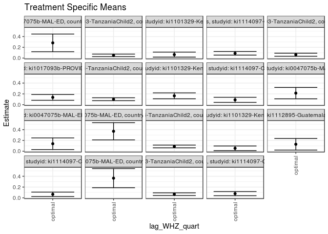

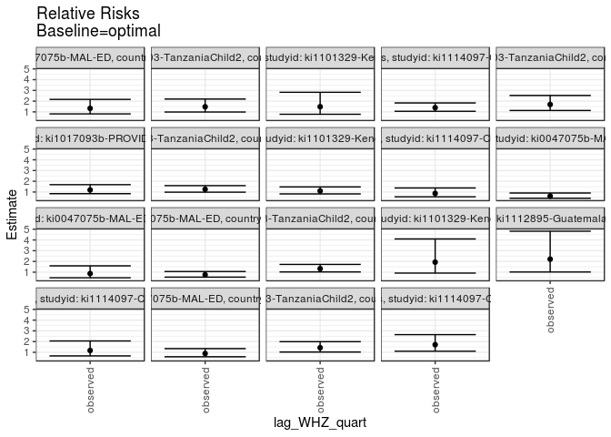

## Results Table

### Parameter: TSM

| agecat | studyid | country | intervention_level | baseline_level | estimate | ci_lower | ci_upper |
| --- | --- | --- | --- | --- | --- | --- | --- |
| 3-6 months | ki1017093b-PROVIDE | BANGLADESH | optimal | NA | 0.1352105 | 0.0812258 | 0.1891951 |
| 3-6 months | ki1066203-TanzaniaChild2 | TANZANIA, UNITED REPUBLIC OF | optimal | NA | 0.1012968 | 0.0742575 | 0.1283360 |
| 3-6 months | ki1101329-Keneba | GAMBIA | optimal | NA | 0.1642012 | 0.1094749 | 0.2189276 |
| 3-6 months | ki1114097-CMIN | PERU | optimal | NA | 0.0894997 | 0.0421349 | 0.1368646 |
| 6-9 months | ki0047075b-MAL-ED | PERU | optimal | NA | 0.2143044 | 0.1089181 | 0.3196908 |
| 6-9 months | ki0047075b-MAL-ED | SOUTH AFRICA | optimal | NA | 0.1393406 | 0.0312784 | 0.2474028 |
| 6-9 months | ki0047075b-MAL-ED | TANZANIA, UNITED REPUBLIC OF | optimal | NA | 0.3701535 | 0.2105373 | 0.5297696 |
| 6-9 months | ki1066203-TanzaniaChild2 | TANZANIA, UNITED REPUBLIC OF | optimal | NA | 0.0885376 | 0.0624075 | 0.1146676 |
| 6-9 months | ki1101329-Keneba | GAMBIA | optimal | NA | 0.0544147 | 0.0113027 | 0.0975268 |
| 6-9 months | ki1112895-Guatemala BSC | GUATEMALA | optimal | NA | 0.1295564 | 0.0224237 | 0.2366890 |
| 6-9 months | ki1114097-CMIN | PERU | optimal | NA | 0.0650238 | 0.0236335 | 0.1064141 |
| 9-12 months | ki0047075b-MAL-ED | TANZANIA, UNITED REPUBLIC OF | optimal | NA | 0.3643104 | 0.1867860 | 0.5418348 |
| 9-12 months | ki1066203-TanzaniaChild2 | TANZANIA, UNITED REPUBLIC OF | optimal | NA | 0.0674220 | 0.0422769 | 0.0925671 |
| 9-12 months | ki1114097-CMIN | PERU | optimal | NA | 0.0779685 | 0.0393228 | 0.1166142 |
| 12-15 months | ki0047075b-MAL-ED | TANZANIA, UNITED REPUBLIC OF | optimal | NA | 0.2823058 | 0.1179561 | 0.4466555 |
| 12-15 months | ki1066203-TanzaniaChild2 | TANZANIA, UNITED REPUBLIC OF | optimal | NA | 0.0511381 | 0.0276221 | 0.0746542 |
| 12-15 months | ki1101329-Keneba | GAMBIA | optimal | NA | 0.0648357 | 0.0182919 | 0.1113795 |
| 12-15 months | ki1114097-CMIN | PERU | optimal | NA | 0.0893279 | 0.0557373 | 0.1229185 |
| 15-18 months | ki1066203-TanzaniaChild2 | TANZANIA, UNITED REPUBLIC OF | optimal | NA | 0.0625400 | 0.0338221 | 0.0912579 |

### Parameter: E(Y)

| agecat | studyid | country | intervention_level | baseline_level | estimate | ci_lower | ci_upper |
| --- | --- | --- | --- | --- | --- | --- | --- |
| 3-6 months | ki1017093b-PROVIDE | BANGLADESH | observed | NA | 0.1613508 | 0.1300924 | 0.1926093 |
| 3-6 months | ki1066203-TanzaniaChild2 | TANZANIA, UNITED REPUBLIC OF | observed | NA | 0.1268012 | 0.1125046 | 0.1410977 |
| 3-6 months | ki1101329-Keneba | GAMBIA | observed | NA | 0.1808511 | 0.1514199 | 0.2102822 |
| 3-6 months | ki1114097-CMIN | PERU | observed | NA | 0.0781250 | 0.0561896 | 0.1000604 |
| 6-9 months | ki0047075b-MAL-ED | PERU | observed | NA | 0.1317365 | 0.0802880 | 0.1831851 |
| 6-9 months | ki0047075b-MAL-ED | SOUTH AFRICA | observed | NA | 0.1213873 | 0.0725817 | 0.1701928 |
| 6-9 months | ki0047075b-MAL-ED | TANZANIA, UNITED REPUBLIC OF | observed | NA | 0.2795031 | 0.2099691 | 0.3490371 |
| 6-9 months | ki1066203-TanzaniaChild2 | TANZANIA, UNITED REPUBLIC OF | observed | NA | 0.1174017 | 0.1019953 | 0.1328080 |
| 6-9 months | ki1101329-Keneba | GAMBIA | observed | NA | 0.1051724 | 0.0801845 | 0.1301603 |
| 6-9 months | ki1112895-Guatemala BSC | GUATEMALA | observed | NA | 0.2865169 | 0.2199085 | 0.3531252 |
| 6-9 months | ki1114097-CMIN | PERU | observed | NA | 0.0761062 | 0.0542221 | 0.0979903 |
| 9-12 months | ki0047075b-MAL-ED | TANZANIA, UNITED REPUBLIC OF | observed | NA | 0.3230769 | 0.2423765 | 0.4037774 |
| 9-12 months | ki1066203-TanzaniaChild2 | TANZANIA, UNITED REPUBLIC OF | observed | NA | 0.0964230 | 0.0802843 | 0.1125618 |
| 9-12 months | ki1114097-CMIN | PERU | observed | NA | 0.1332046 | 0.1039145 | 0.1624947 |
| 12-15 months | ki0047075b-MAL-ED | TANZANIA, UNITED REPUBLIC OF | observed | NA | 0.3736264 | 0.2736811 | 0.4735717 |
| 12-15 months | ki1066203-TanzaniaChild2 | TANZANIA, UNITED REPUBLIC OF | observed | NA | 0.0752119 | 0.0583791 | 0.0920447 |
| 12-15 months | ki1101329-Keneba | GAMBIA | observed | NA | 0.0959596 | 0.0669135 | 0.1250057 |
| 12-15 months | ki1114097-CMIN | PERU | observed | NA | 0.1241685 | 0.0936995 | 0.1546375 |
| 15-18 months | ki1066203-TanzaniaChild2 | TANZANIA, UNITED REPUBLIC OF | observed | NA | 0.1056241 | 0.0832975 | 0.1279508 |

### Parameter: RR

| agecat | studyid | country | intervention_level | baseline_level | estimate | ci_lower | ci_upper |
| --- | --- | --- | --- | --- | --- | --- | --- |
| 3-6 months | ki1017093b-PROVIDE | BANGLADESH | observed | optimal | 1.1933311 | 0.8448259 | 1.6856005 |
| 3-6 months | ki1066203-TanzaniaChild2 | TANZANIA, UNITED REPUBLIC OF | observed | optimal | 1.2517789 | 0.9840340 | 1.5923742 |
| 3-6 months | ki1101329-Keneba | GAMBIA | observed | optimal | 1.1013991 | 0.8219712 | 1.4758180 |
| 3-6 months | ki1114097-CMIN | PERU | observed | optimal | 0.8729075 | 0.5536702 | 1.3762119 |
| 6-9 months | ki0047075b-MAL-ED | PERU | observed | optimal | 0.6147168 | 0.4160808 | 0.9081811 |
| 6-9 months | ki0047075b-MAL-ED | SOUTH AFRICA | observed | optimal | 0.8711550 | 0.4775595 | 1.5891446 |
| 6-9 months | ki0047075b-MAL-ED | TANZANIA, UNITED REPUBLIC OF | observed | optimal | 0.7551006 | 0.5374652 | 1.0608630 |
| 6-9 months | ki1066203-TanzaniaChild2 | TANZANIA, UNITED REPUBLIC OF | observed | optimal | 1.3260093 | 1.0205400 | 1.7229119 |
| 6-9 months | ki1101329-Keneba | GAMBIA | observed | optimal | 1.9327926 | 0.9128101 | 4.0925133 |
| 6-9 months | ki1112895-Guatemala BSC | GUATEMALA | observed | optimal | 2.2115225 | 1.0162330 | 4.8127067 |
| 6-9 months | ki1114097-CMIN | PERU | observed | optimal | 1.1704359 | 0.6650518 | 2.0598700 |
| 9-12 months | ki0047075b-MAL-ED | TANZANIA, UNITED REPUBLIC OF | observed | optimal | 0.8868178 | 0.5854323 | 1.3433590 |
| 9-12 months | ki1066203-TanzaniaChild2 | TANZANIA, UNITED REPUBLIC OF | observed | optimal | 1.4301427 | 1.0278411 | 1.9899071 |
| 9-12 months | ki1114097-CMIN | PERU | observed | optimal | 1.7084420 | 1.1026688 | 2.6470089 |
| 12-15 months | ki0047075b-MAL-ED | TANZANIA, UNITED REPUBLIC OF | observed | optimal | 1.3234810 | 0.8097263 | 2.1632025 |
| 12-15 months | ki1066203-TanzaniaChild2 | TANZANIA, UNITED REPUBLIC OF | observed | optimal | 1.4707589 | 0.9862382 | 2.1933158 |
| 12-15 months | ki1101329-Keneba | GAMBIA | observed | optimal | 1.4800430 | 0.7756675 | 2.8240545 |
| 12-15 months | ki1114097-CMIN | PERU | observed | optimal | 1.3900309 | 1.0551968 | 1.8311143 |
| 15-18 months | ki1066203-TanzaniaChild2 | TANZANIA, UNITED REPUBLIC OF | observed | optimal | 1.6889053 | 1.1289944 | 2.5264970 |

### Parameter: PAR

| agecat | studyid | country | intervention_level | baseline_level | estimate | ci_lower | ci_upper |
| --- | --- | --- | --- | --- | --- | --- | --- |
| 3-6 months | ki1017093b-PROVIDE | BANGLADESH | optimal | NA | 0.0261404 | -0.0207337 | 0.0730144 |
| 3-6 months | ki1066203-TanzaniaChild2 | TANZANIA, UNITED REPUBLIC OF | optimal | NA | 0.0255044 | 0.0009900 | 0.0500187 |
| 3-6 months | ki1101329-Keneba | GAMBIA | optimal | NA | 0.0166498 | -0.0315063 | 0.0648060 |
| 3-6 months | ki1114097-CMIN | PERU | optimal | NA | -0.0113747 | -0.0521703 | 0.0294208 |
| 6-9 months | ki0047075b-MAL-ED | PERU | optimal | NA | -0.0825679 | -0.1657563 | 0.0006205 |
| 6-9 months | ki0047075b-MAL-ED | SOUTH AFRICA | optimal | NA | -0.0179533 | -0.1031846 | 0.0672779 |
| 6-9 months | ki0047075b-MAL-ED | TANZANIA, UNITED REPUBLIC OF | optimal | NA | -0.0906503 | -0.2196085 | 0.0383078 |
| 6-9 months | ki1066203-TanzaniaChild2 | TANZANIA, UNITED REPUBLIC OF | optimal | NA | 0.0288641 | 0.0054457 | 0.0522824 |
| 6-9 months | ki1101329-Keneba | GAMBIA | optimal | NA | 0.0507577 | 0.0084680 | 0.0930473 |
| 6-9 months | ki1112895-Guatemala BSC | GUATEMALA | optimal | NA | 0.1569605 | 0.0522264 | 0.2616946 |
| 6-9 months | ki1114097-CMIN | PERU | optimal | NA | 0.0110824 | -0.0257822 | 0.0479470 |
| 9-12 months | ki0047075b-MAL-ED | TANZANIA, UNITED REPUBLIC OF | optimal | NA | -0.0412335 | -0.1930061 | 0.1105391 |
| 9-12 months | ki1066203-TanzaniaChild2 | TANZANIA, UNITED REPUBLIC OF | optimal | NA | 0.0290011 | 0.0062925 | 0.0517096 |
| 9-12 months | ki1114097-CMIN | PERU | optimal | NA | 0.0552362 | 0.0193368 | 0.0911355 |
| 12-15 months | ki0047075b-MAL-ED | TANZANIA, UNITED REPUBLIC OF | optimal | NA | 0.0913206 | -0.0471211 | 0.2297622 |
| 12-15 months | ki1066203-TanzaniaChild2 | TANZANIA, UNITED REPUBLIC OF | optimal | NA | 0.0240737 | 0.0029874 | 0.0451600 |
| 12-15 months | ki1101329-Keneba | GAMBIA | optimal | NA | 0.0311239 | -0.0116652 | 0.0739130 |
| 12-15 months | ki1114097-CMIN | PERU | optimal | NA | 0.0348406 | 0.0090943 | 0.0605870 |
| 15-18 months | ki1066203-TanzaniaChild2 | TANZANIA, UNITED REPUBLIC OF | optimal | NA | 0.0430841 | 0.0165004 | 0.0696678 |

### Parameter: PAF

| agecat | studyid | country | intervention_level | baseline_level | estimate | ci_lower | ci_upper |
| --- | --- | --- | --- | --- | --- | --- | --- |
| 3-6 months | ki1017093b-PROVIDE | BANGLADESH | optimal | NA | 0.1620096 | -0.1836758 | 0.4067396 |
| 3-6 months | ki1066203-TanzaniaChild2 | TANZANIA, UNITED REPUBLIC OF | optimal | NA | 0.2011369 | -0.0162250 | 0.3720069 |
| 3-6 months | ki1101329-Keneba | GAMBIA | optimal | NA | 0.0920639 | -0.2165876 | 0.3224097 |
| 3-6 months | ki1114097-CMIN | PERU | optimal | NA | -0.1455968 | -0.8061294 | 0.2733677 |
| 6-9 months | ki0047075b-MAL-ED | PERU | optimal | NA | -0.6267654 | -1.4033792 | -0.1011019 |
| 6-9 months | ki0047075b-MAL-ED | SOUTH AFRICA | optimal | NA | -0.1479013 | -1.0939801 | 0.3707306 |
| 6-9 months | ki0047075b-MAL-ED | TANZANIA, UNITED REPUBLIC OF | optimal | NA | -0.3243268 | -0.8605854 | 0.0573712 |
| 6-9 months | ki1066203-TanzaniaChild2 | TANZANIA, UNITED REPUBLIC OF | optimal | NA | 0.2458575 | 0.0201266 | 0.4195873 |
| 6-9 months | ki1101329-Keneba | GAMBIA | optimal | NA | 0.4826139 | -0.0955181 | 0.7556514 |
| 6-9 months | ki1112895-Guatemala BSC | GUATEMALA | optimal | NA | 0.5478228 | 0.0159737 | 0.7922167 |
| 6-9 months | ki1114097-CMIN | PERU | optimal | NA | 0.1456175 | -0.5036422 | 0.5145325 |
| 9-12 months | ki0047075b-MAL-ED | TANZANIA, UNITED REPUBLIC OF | optimal | NA | -0.1276274 | -0.7081395 | 0.2555973 |
| 9-12 months | ki1066203-TanzaniaChild2 | TANZANIA, UNITED REPUBLIC OF | optimal | NA | 0.3007691 | 0.0270869 | 0.4974640 |
| 9-12 months | ki1114097-CMIN | PERU | optimal | NA | 0.4146714 | 0.0931094 | 0.6222151 |
| 12-15 months | ki0047075b-MAL-ED | TANZANIA, UNITED REPUBLIC OF | optimal | NA | 0.2444168 | -0.2349853 | 0.5377224 |
| 12-15 months | ki1066203-TanzaniaChild2 | TANZANIA, UNITED REPUBLIC OF | optimal | NA | 0.3200789 | -0.0139538 | 0.5440693 |
| 12-15 months | ki1101329-Keneba | GAMBIA | optimal | NA | 0.3243439 | -0.2892123 | 0.6458992 |
| 12-15 months | ki1114097-CMIN | PERU | optimal | NA | 0.2805916 | 0.0523095 | 0.4538844 |
| 15-18 months | ki1066203-TanzaniaChild2 | TANZANIA, UNITED REPUBLIC OF | optimal | NA | 0.4079005 | 0.1142560 | 0.6041951 |